# Tutorial_PreprocessingClustering_SCdata

https://scanpy.readthedocs.io/en/stable/tutorials/basics/clustering.html

- Scanpy와 인터넷에 공개된 scRNA 데이터를 받고, 이 데이터에 대한 QC 및 clustering을 진행해본다.

## Setup

```python
import scanpy as sc
import anndata as ad
import pooch
sc.settings.set_figure_params(dpi=50, facecolor="white")
```

```python
#Download data
EXAMPLE_DATA = pooch.create(path=pooch.os_cache("scverse_tutorials"),
                            base_url="doi:10.6084/m9.figshare.22716739.v1/")
EXAMPLE_DATA.load_registry_from_doi()
```

- 사용된 데이터는 [openproblem's NeurlPS 2021 benchmarking dataset](https://openproblems.bio/competitions/neurips_2021/)에서 유래한다
- 이 데이터는 인간의 bone marrow mononuclear cells 데이터이다
- 이 데이터는 10x Multiome Gene Expression과 Chromain Accessability kit을 통해 생산되었다.

```python
#Assign data to 'AnnData' object
adatas = {}

samples = {"s1d1": "s1d1_filtered_feature_bc_matrix.h5",
           "s1d3": "s1d3_filtered_feature_bc_matrix.h5"}
for sample_id, filename in samples.items():
    path = EXAMPLE_DATA.fetch(filename)
    sample_adata = sc.read_10x_h5(path)
    sample_adata.var_names_make_unique()
    adatas[sample_id] = sample_adata

adata = ad.concat(adatas, label="sample")
```

```python
#Data summary
adata.obs_names_make_unique()
print(adata.obs["sample"].value_counts())
adata
```

```
s1d1    8785
s1d3    8340
Name: sample, dtype: int64
```

```
AnnData object with n_obs × n_vars = 17125 × 36601
    obs: 'sample'
```

## Quality Control

- `calculate_qc_metrics()` 함수를 실행하면 QC metrics를 계산하게 된다.

```python
#Define the prefixes of mitochondrial, ribosomal and hemoglobin genes
adata.var["mt"] = adata.var_names.str.startswith("MT-") #mitochondrial genes
adata.var["ribo"] = adata.var_names.str.startswith(("RPS", "RPL")) #ribosomal genes
adata.var["hb"] = adata.var_names.str.contains("^HB[^(P)]") #hemoglobin genes
```

```python
#Quality control
sc.pp.calculate_qc_metrics(adata, qc_vars=["mt", "ribo", "hb"], inplace=True, log1p=True)
```

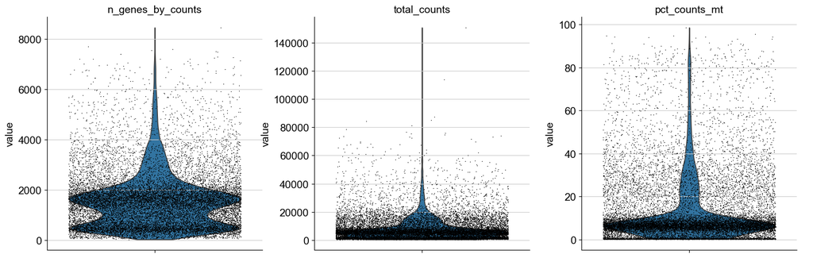

```python
#Visualize the QC result: "n_genes_by_counts", "total_counts", "pct_counts_mt"
sc.pl.violin(adata, ["n_genes_by_counts", "total_counts", "pct_counts_mt"], jitter=0.4, multi_panel=True)
```

- QC 이후 다음 세 개의 영역에 따라 시각화가 수행되었다. 1) Count matrix 내 발현된 유전자의 수 2) 세포 당 total count 3) 미토콘드리아 유전자 count의 비율

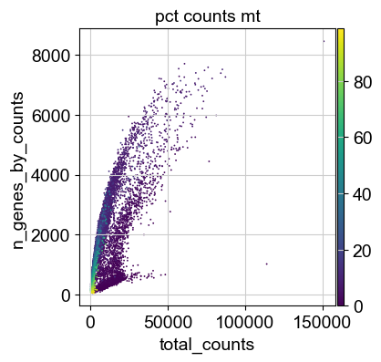

```python
#Visualize the QC result: all together
sc.pl.scatter(adata, "total_counts", "n_genes_by_counts", color="pct_counts_mt")
```

- QC 결과를 시각화하여 filter out에 대한 기준을 마련할 수 있다.
- 그러나 시각화 결과에서 눈대중으로 기준을 정하는 것은 쉽지 않다.
- 때로는 데이터가 경계가 분명하게 나오지 않을 수 있기 때문이다.
- 이번 튜토리얼에서는 유전자 100 이하, 세포 수 3 이하의 세포를 filter out하기로 한다.

```python
sc.pp.filter_cells(adata, min_genes=100)
sc.pp.filter_genes(adata, min_cells=3)
```

## Doublet detection algorithm

- Doublet을 확인하는 작업은 중요하다.
- Doublet은 misclassification 혹은 downstream 분석 과정에서 왜곡된 결과를 유도할 수 있기 때문이다.
- Scanpy의 경우 Scrublet이라는 방법으로 통해 doublet을 확인한다.
  - Scrublet은 nearest-neighbor classifier를 통해 cell doublets를 예측한다.
  - Scrublet을 수행하고 나면 데이터에 doublet_score와 predicted_doublet 컬럼이 추가된다. 이를 필터링의 기준으로 후에 사용할 수 있게 된다.

```python
sc.pp.scrublet(adata, batch_key="sample")
```

## Normalization

- 주요한 normalization 방법으로는 log plus one(log1p) transformation에 따른 count depth scaling 방법이 있다.
- Coutn depth scaling 방법은 데이터를 "size facor"로 normalization 시킨다.
  - Size factor로는 median count depth, CP10K, CPM 등이 있다.
- 이번 튜토리얼에서는 log1PF 방법을 통해 median count depth normalization을 수행한다.

```python
#Backup count data
adata.layers["counts"] = adata.X.copy()
```

```python
#Normalizing to median total counts
sc.pp.normalize_total(adata)

#Logarithmize the data
sc.pp.log1p(adata)
```

## Feature Selection

- 데이터 차원 축소를 통해 가장 사용할만한 유전자만 남기려는 경우를 feature selection이라고도 부른다.
- Scanpy는 `high_variable_genes`이라는 기능을 지원한다. 해당 기능은 Seurat, Cell Ranger, Seurat v3 기능을 구현한 것이다.

```python
sc.pp.highly_variable_genes(adata, n_top_genes=2000, batch_key="sample")
```

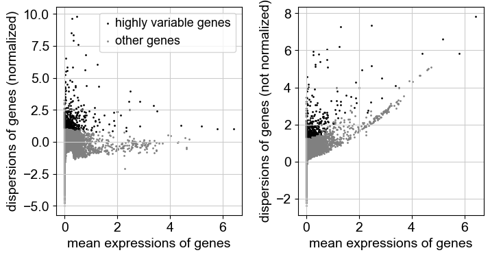

```python
sc.pl.highly_variable_genes(adata)
```

## Dimensionality Reduction

- 주성분분석(Principal Component Analysis, PCA)을 수행하여, variation의 주성분을 파악하고 데이터의 노이즈를 제거한다(denoise)

```python
sc.tl.pca(adata)
```

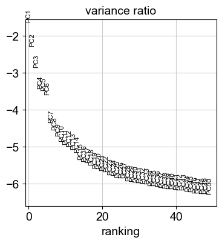

```python
#Inspect the contribution of single PCs to the total variance
sc.pl.pca_variance_ratio(adata, n_pcs=50, log=True)
```

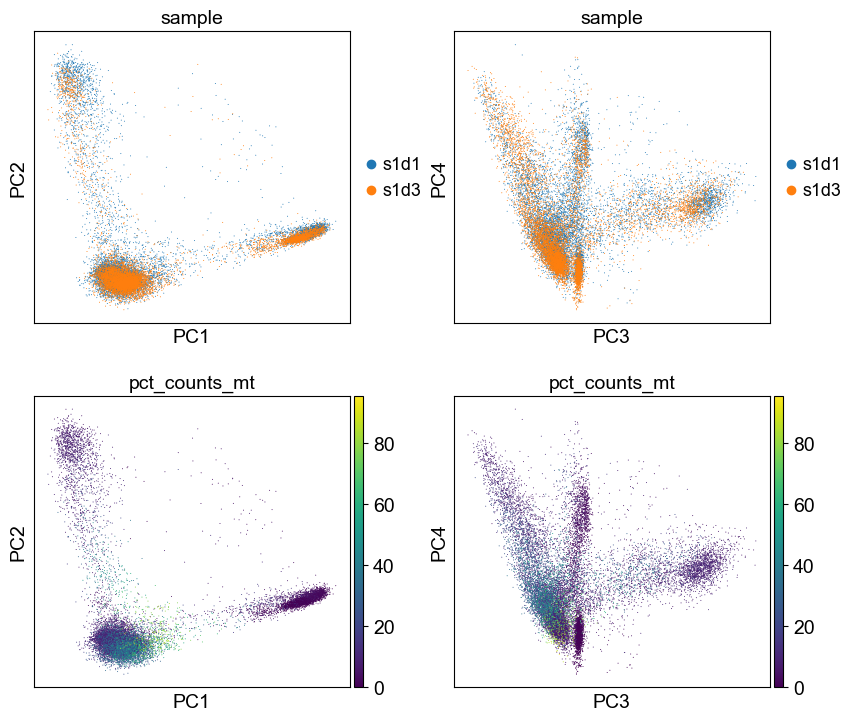

```python
#Visualize the PCA
sc.pl.pca(adata, color=["sample", "sample", "pct_counts_mt", "pct_counts_mt"], dimensions=[(0, 1), (2, 3), (0, 1), (2, 3)], ncols=2, size=2)
```

- PCA 시각화를 통하여 필요하지 않는 features(batch, QC metrics 등)이 있는지 파악한다.

## Nearest neightbor graph construction and visualization

- PCA 결과를 이용하여 neighborhood graph를 그린다.

```python
#Compute nearest neighbors
sc.pp.neighbors(adata)
```

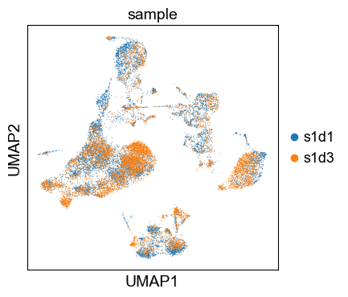

```python
#Visualize with UMAP
sc.tl.umap(adata)
sc.pl.umap(adata, color="sample", size=2)
```

- Batch effect는 많이 관찰되지 않는다.
- 만약 batch effect를 관찰했다면 samples들을 integrate 하거나 batch correction을 수행하는 것이 좋다.

## Clustering

- Leiden graph-clustering 방법이 clustering 방법으로 주로 추천된다.
- 그러나 `sc.pl.leiden`의 경우 현재 64비트 windows와 scanpy에서 사용하는 numpy 1.24.4 사이의 오류 출력 문제로 windows 환경의 jupyter notebook에서 사용하기는 좋지 않다.
- 따라서 louvain을 이용해서 clustering을 수행한다.

```python
sc.tl.louvain(adata, key_added='louvain_r1')
```

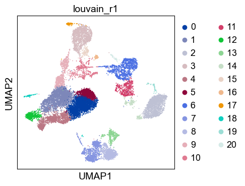

```python
#Visualize
sc.pl.umap(adata, color=['louvain_r1'])
```

## Re-assess QC and cell filtering

- UMAP을 이용하여 서로 다른 QC metrics를 시각화한다.
- 이를 통해 filtering 과정을 다시 수행할 수 있게 된다.

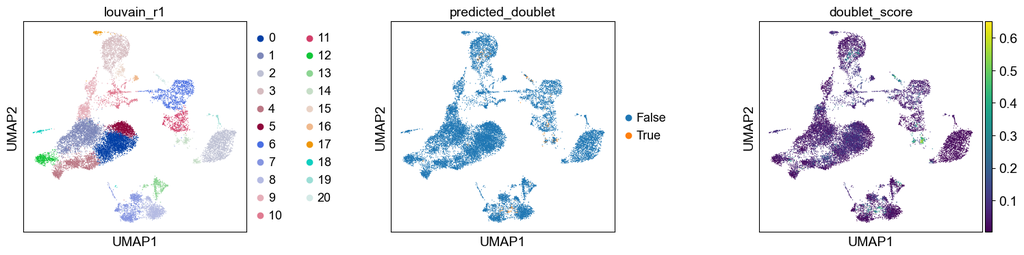

```python
sc.pl.umap(adata, color=["louvain_r1", "predicted_doublet", "doublet_score"], wspace=0.5, size=3)
```

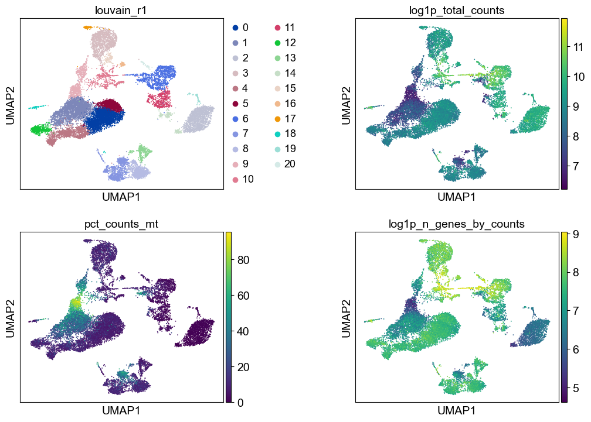

```python
sc.pl.umap(adata, color=["louvain_r1", "log1p_total_counts", "pct_counts_mt", "log1p_n_genes_by_counts"], wspace=0.5, ncols=2)
```